# Homework 1

```r
library(dplyr)
```

## Problem 1 (2pts each, 8pts total)

Here are a few probability exercises to get you warmed up.

1. Consider $X\sim \text{Normal}(5, 2^2)$. Find $P(4 < X < 7)$

```r
q1a_x = pnorm(7, 5, 2)
q1a_y = pnorm(4, 5, 2)
q1a = q1a_x - q1a_y
q1a
```

```
## [1] 0.5328072
```

2. Suppose you have an uneven 6-sided die where the even numbers are equally likely to occur and the odd numbers are also equally likely. The expected value of the die is $3.3333$ (i.e. $\frac{10}{3})$. What is the probability of getting a 6? (Hint: Let $p$ represent the probability of getting an even number, and represent the probability of the other numbers algebraically. Then derive an expression for the expected value, let it equal $\frac{10}{3}$, and solve. You can go back and check your work by plugging the result back into your original expressions and verify it works with R.) Variables: p (prob of getting an even number), 1 - p (prob of getting an odd number) Solution:

1((1 - p)/3) + 2p/3 + 3((1 - p)/3) + 4p/3 + 5((1 - p)/3) + 6p/3 = 10/3 1/3 - p/3 + 2p/3 + 1 - p + 4p/3 + 5/3 - 5p/3 + 6p/3 = 10/3 3 + p = 10/3 p = 1/3, * 1/3 to get 1/9, 11.11%

3. Give **two examples** of pairs of events that are mutually exclusive and explain why for each. Rolling a die and getting a 2 or a 4. If you roll a 6 sided die, you can either get a 2 or a 4, but not both in a single roll. Since these events cannot occur simutaneously, they are mutually exclusive. Another example of something being mutually exclusive is a coin flip. You will either get heads or tails obviously but you cannot get both of them at the same time, therefore they are mutually exclusive.
4. Give **two examples** of pairs of events that are independent and explain why for each. An example of an independent event is rolling a die and flipping a coin. The result of flipping the coin will not influence the result from the die whatsoever. Since the outcome does not affect the other, they are independent. Another example of this is drawing a card from a deck and rolling a die. Suppose you draw a card from a deck (King of Spades) and then roll a 6 sided die. The result of drawing a card does not change the probability of getting a specific number from the die.

## Problem 2 (2pts each, 14pts total)

For each of the following scenarios, decide what random variable may be appropriate to use as a model, and explain your reasoning as well as any assumptions you make.

1. The number of patients in an experimental drug trial that respond to treatment. In this scenario, the random variable X can represent the number of patients in an experimental drug trial that respond to treatment. This would be an example of a binomial distribution, as this scenario follows the BINS acronym (binary outcomes, independent trials, fixed number of trials, and same probability of success) and because we are measuring a simple binary outcome of whether or not patients have a response to treatment.
2. The number of red cars you observe driving through an intersection between 10am and 11am. The random variable X here can represent the number of red cars observed driving through an intersection between 10 am and 11 am. This would be an example of a Poisson distribution, because in this scenario, cars are being counted as “arrivals” during a certain unit of time (a one hour block).
3. What the second hand reads on the clock when you wake up (without an alarm clock) from a long nap (approximately). The random variable X here can represent what the second hand of the clock says when you wake up from a nap. This would be a good example of a discrete uniform distribution because in this scenario, 60 seconds is a continuous interval. The hand has the same probability of the landing on each second and it is impossible for the hand to land on a non integer.
4. How many people you need to swipe right on Tinder before you get a match. The random variable X here can represent the amount of people you need to swipe right on Tinder before you get a match. This is a good example of a geometric distribution as each swipe is an independent trial with two possible outcomes: match or no match. This process continues until you are able to find a match or your first success, making it a clear geometric distribution scenario.
5. The length of time between mosquito bites a camper experiences while on a hike. The random variable X here can represent the length of time between mosquito bites a camper experiences while on a hike. This would be an example of an exponential distribution, as this scenario measures the time between each mosquito bite in a Poisson-type event.
6. Whether the Eagles win the Superbowl this year. The random variable X here can represent whether or not the Eagles win the Superbowl this year. This is an example of a binomial distribution. It is measuring a win/loss event, win being the Eagles win the SB and loss being the Eagles don’t win the SB.
7. The GPA of a randomly selected UW-Madison graduate. The random variable X here can represent the GPA of the randomly selected UW-Madison graduate. This is an example of a normal distribution, assuming that this distribution follows a bell-shaped curve and is symmetrical at the mean, because most similar scenarios have a normal distribution (ACT scores).

## Problem 3 (2pts each, 4pts total)

1. Consider the CDF given below for random variable $Y$

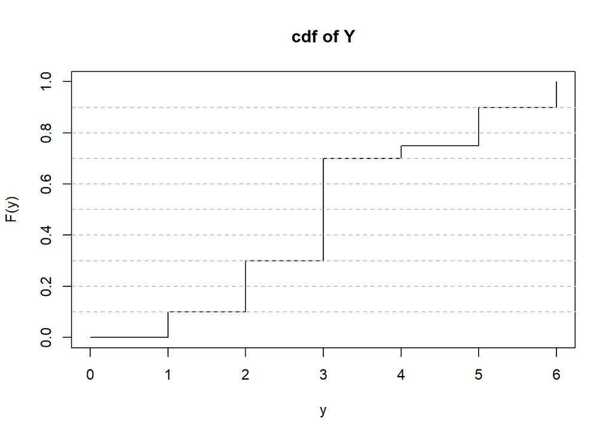

```r
plot(x=0:6, y=c(0,.1,.3, .7, .75,.9,1), type="s", ylab="F(y)", xlab="y", main="cdf of Y")
abline(h=seq(.1,.9,.1), lty=2, col="gray")
```

Express the pmf of $Y$ in the following R code (in other words, fill in the missing probabilities)

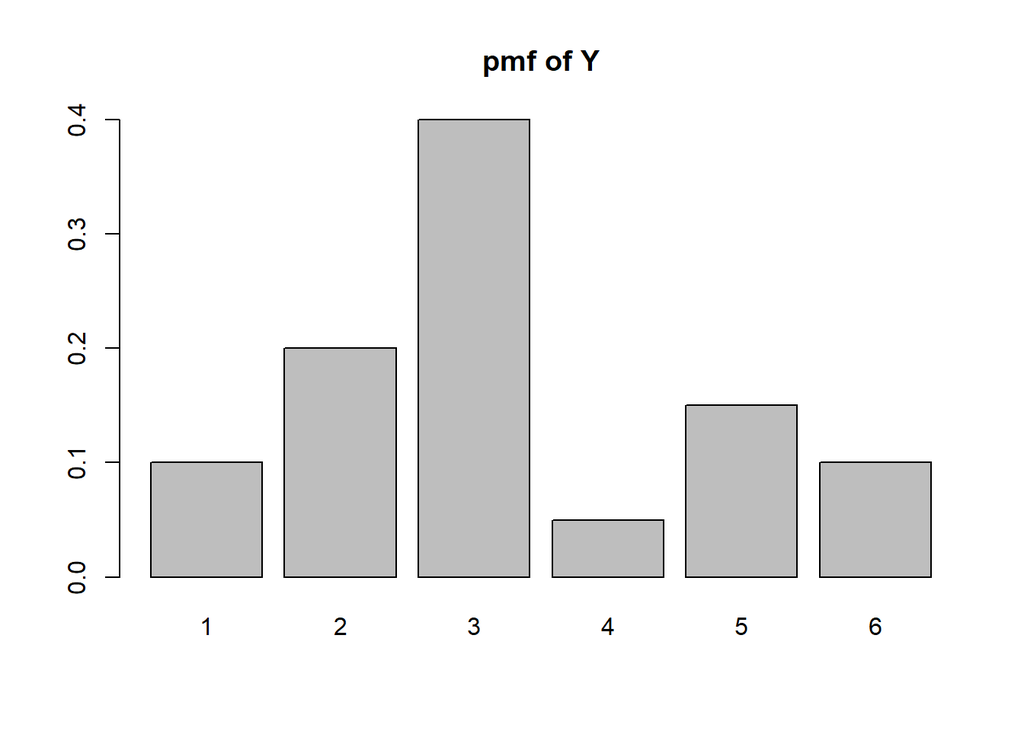

```r
y<- 1:6
py <- c(0.1, .2, .4, .05, .15, .1) ## edit this line
barplot(height=py, names=y, main="pmf of Y")
```

2. Calculate $E[Y]$ for the variable $Y$ in part a. E[Y] = (1x0.1)+(2x0.2)+(3x0.4)+(4x0.05)+(5x0.15)+(6x0.1) = 3.25

## Problem 4 (2pts each, 4pts total)

Below you will find the plot of a probability density function for a random variable $X$.

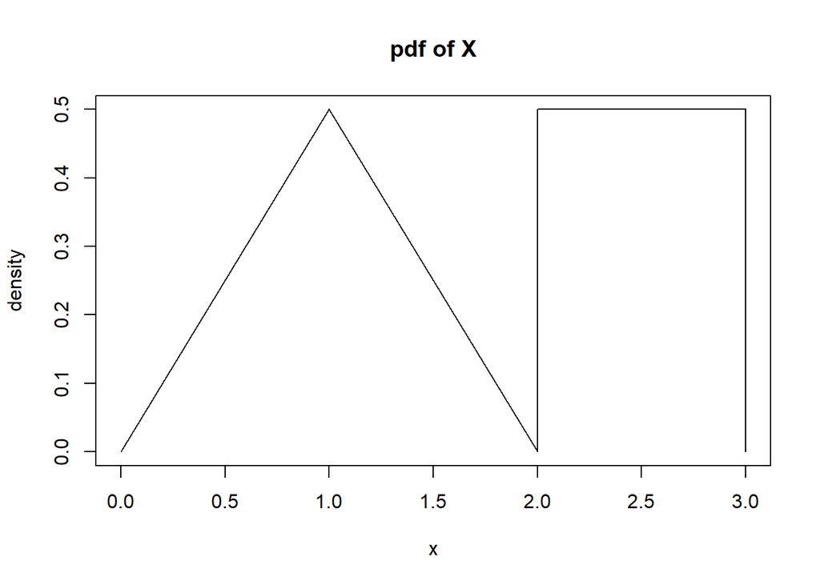

Using just geometry answer a and b:

1. What is $Pr[X < 1]$? P(X < 1) = .25
2. What is $Pr[1.5 < X < 2.5]$ P(1.5 < X < 2.5) = .3125